# Student Debt Accumulation Between Different Races and the Long Term Effects

Samin Charepoo

Mini Project 1 – March 1st 2021

```r
# Load any R Packages you may need
library(tidyverse)
library(mdsr)
library(mosaic)
library(ggplot2)
```

```r
student_debt <- readr::read_csv('https://raw.githubusercontent.com/rfordatascience/tidytuesday/master/data/2021/2021-02-09/student_debt.csv')
home_owner <- readr::read_csv('https://raw.githubusercontent.com/rfordatascience/tidytuesday/master/data/2021/2021-02-09/home_owner.csv')
race_wealth <- readr::read_csv('https://raw.githubusercontent.com/rfordatascience/tidytuesday/master/data/2021/2021-02-09/race_wealth.csv')
race_wealth_c<-na.omit(race_wealth)
race_wealth_clea<-race_wealth_c[!(race_wealth_c$race=="Non-White"),]
race_wealth_clea1<-race_wealth_clea[!(race_wealth_clea$year=="1963"),]
race_wealth_clean<-race_wealth_clea1[!(race_wealth_clea1$type=="Median"),]
```

## Looking at the Difference In Student Debt Between Black, White and Hispanic Students

Student debt affects more than 40 million Americans in 2021. The burden of that debt varies across gender, location, demographic, and very strongly, race. There is a growing library of research which points to the apparent inequality in student debts held by students of color. This statistical analysis will look deeper into the difference in dept accumulation between Black, Hispanic and White Students as well as dive into how this debt could possibly effect other long term financial factors such as home ownership and average income.

The data set used here is the *student_debt* data set from *TidyTuesday* on *GitHub* showing average student debt amount in US dollars between White, Black and Hispanic students from the years 1989-2016.

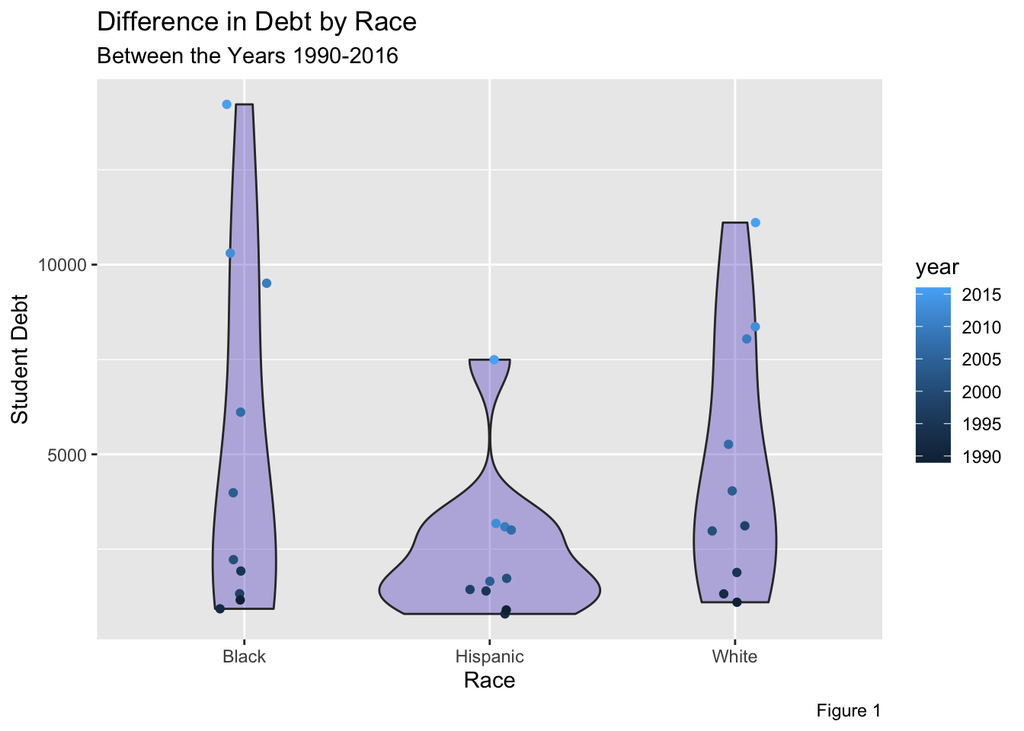

```r
ggplot(data=student_debt, aes(x=race, y=loan_debt, color=year))+
  geom_violin(fill="slateblue", alpha=0.4)+
  geom_jitter(height = 0, width=0.1)+
  labs(x="Race",y="Student Debt", title="Difference in Debt by Race", subtitle = 'Between the Years 1990-2016',caption = "Figure 1")
```

This violin graph above shows the uneven distribution between students who are Black, White and Hispanic in regard to their student debt. We see that on average, in the year 2015, Black students have the largest student debt with an average of around $14,000, followed by White students with an average of about $11,000, then lastly Hispanic students with the lowest amount of around $7,000, about half the amount as Black students! The color aesthetic seen on the right side of the graph shows the variable *year* and creates different shades of blue for each year the data set shows so we can distinct what year the parts of the graph are accounting for. We can see that as time goes on, debt is significantly rising between all races, especially Black students. It is interesting to see that in the years from 1990-2000, although there was still a difference in student debt between the races, it wasn’t until after the year 2000 that it became such a drastic inequality. A *geom_violin* object was used for figure one because there was one categorical variable and one numerical variable. It also shows the density of where most of the debt lies, as well as the range of debt students.

We see that throughout the years, student debt has increased tremendously overall as well as disproportionately in regards to race. We can not infer the specific reason for this striking difference, but definitely makes you wonder what long term effects this may have on these students.

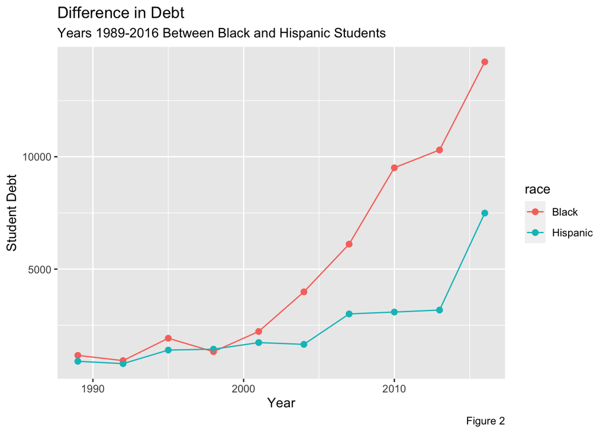

```r
highLow<-student_debt[!(student_debt$race=="White"),]
ggplot(data = highLow, mapping = aes(x = year, y = loan_debt, color = race)) +
  geom_point(size = 2) +
  geom_line(se = FALSE)+
  labs(x="Year",y="Student Debt", title="Difference in Debt",subtitle = "Years 1989-2016 Between Black and Hispanic Students",caption = "Figure 2")
```

## Wealth and Home Ownership by Race

Now that we have seen this apparent disproportion in student debt between Black, Hispanic and White Students, lets look at some of the long term effects that might have. The data we are looking at is from two data sets, *race_wealth* and *home_owner* from *TidyTuesday* on Github. The “race_wealth” shows the average family wealth by race (Black, White and Hispanic) and year (1983-2016). The “home_owner” data shows home ownership percentage for families by race (Black, White and Hispanic) and year (1976-2016)

[figure not shown]

```r
p2<-ggplot(data=race_wealth_clean, aes(x=year, y=wealth_family, color=race))+
  geom_boxplot()+
  labs(x="Year",y="Average Wealth", title="Average Family Wealth by Race",caption = "Figure 3")
p2
```

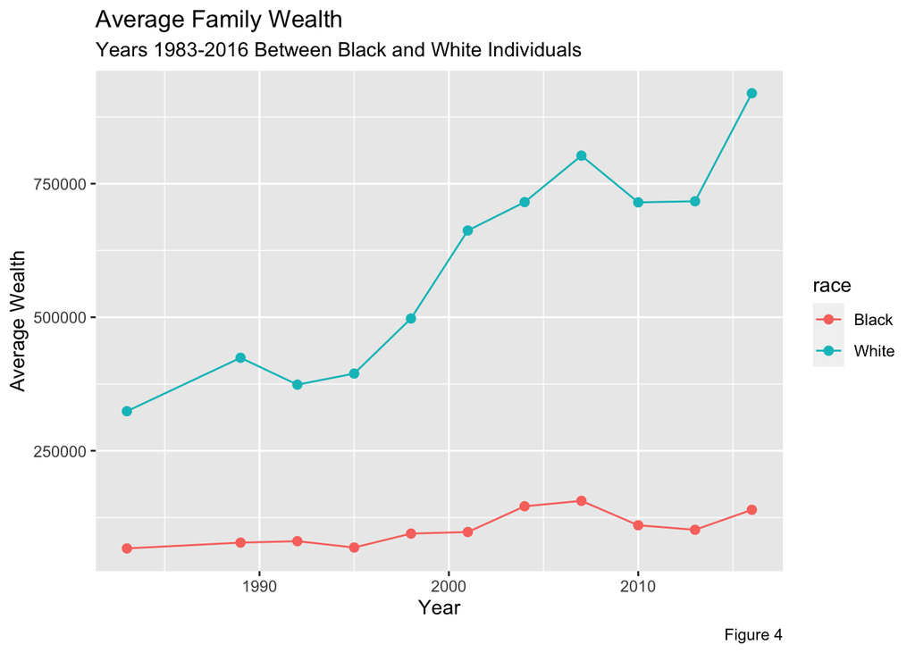

```r
HighestLowest<-race_wealth_clean[!(race_wealth_clean$race=="Hispanic"),]
p1<-ggplot(data = HighestLowest, mapping = aes(x = year, y = wealth_family, color=race)) +
  geom_point(size = 2, aes(color= race, size=loan_debt)) +
  geom_line() +
  labs(x="Year",y="Average Wealth", title="Average Family Wealth", subtitle = "Years 1983-2016 Between Black and White Individuals", caption="Figure 4")
p1
```

Looking at figure 5 below on home ownership, we see a big gap between Black and Hispanic versus White individuals. There are two dips throughout the years between all three races, but it seems to stay within the same range for each. Looking closely, the lowest the percent of White homers is always above 65%, while the highest percentage of Black and Hispanic homeowners never rises above 50%. This is a huge disparity! Just like with the *Wealth by Race* visualization above, we can not necessarily link the proportion of student debt with the percentage of home ownership by race, but it might still play a factor. If one has more debt, they are more likely to not be able to afford a down payment and mortgage on a home, but we see that white students, although second highest in student debt, are incredibly more likely to own a home which again shows us that there are many other systemic factors playing into this unequal distribution of home ownership percentage by race. A *geom_point* and *geom_smooth* object were used since it was two numeric variables and to show the trend of home ownership throughout the years to get a bigger picture of how the distribution falls. I used a *facet_wrap* to separate the three races to have a clear visual of the three as Black and Hispanic data was similar. The color aesthetic of *race* was used to categorize and color-code the different races.

[figure not shown]